# Data Exploration

Fadi Murad

June 1, 2018

This R Markdown document contains the data exploration step for this project which includes loading data, prepare data and taking a look at each variable in order to understand the data  
For this project, we’ve taken the data set from UCI Machine Learning Repository, you can find zip files (train set & test set) in the folder *1-Data_Set* these files contain column names and ready to be loaded, but due to the huge sizes of this files I’ve already created train and test RData files to be used in this project.

## A. ِِLoading and Checking Data

First, we will load the train and test set and take a look, we will call the train dataset *tr* and the test set *test* and we will use it for the whole project

```r
#load needed package for this step:
library(readr)
library(rmarkdown)
library(dplyr)
library(ggplot2)
library(tinytex)
library(gridExtra)
library(corrplot)

#import train data set
load(file="tr.RData")
load(file="test.RData")
```

```r
#View train set
str(tr)
Hmisc::describe(tr)

str(test)
Hmisc::describe(test)
```

The train data has 199,523 rows and 41 columns while the train set has 99,762 rows and 41 columns, also we can notice that most of the variables class needed to be modified, but first let us start with the target variable (income_level)

```r
unique(tr$income_level)
```

```
[1] -50000  50000
```

```r
prop.table(table(tr$income_level)) #value distribution
```

```
    -50000      50000
0.93794199 0.06205801
```

```r
summarise(group_by(tr,income_level),n=n()) #values count
```

```
# A tibble: 2 x 2
  income_level      n
         <int>  <int>
1       -50000 187141
2        50000  12382
```

```r
unique(test$income_level)
```

```
[1] "-50000"  "50000+."
```

```r
prop.table(table(test$income_level)) #value distribution
```

```
    -50000    50000+.
0.93799242 0.06200758
```

```r
summarise(group_by(test,income_level),n=n()) #values count
```

```
# A tibble: 2 x 2
  income_level     n
  <chr>        <int>
1 -50000       93576
2 50000+.       6186
```

As this is a binary classification problem, I will encode the income_level to 0 & 1 instead of -50000 & +50000 (please note there is a difference in the format of this column between train and test set) also I will add new income_level_1 column but with logical class (TRUE & FALSE), each column will be useful for different uses in the following steps.

```r
#Changing income level values to 0 and 1
tr$income_level[tr$income_level==-50000] <- 0
tr$income_level[tr$income_level==+50000] <- 1

test$income_level[test$income_level=="-50000"] <- 0
test$income_level[test$income_level=="50000+."] <- 1
```

Now let us go back to the other variables in the data set, as we noticed before (using str function) there is a need to change the class of most of the variables according to thier nature

```r
#Creating vectors contains the columns index for categorical and numeric columns
catcol <- c(2:5,7,8:16,20:29,31:38,40)
numcol <- c(setdiff(1:40,catcol),41)

#set the class for each column
tr[numcol]<-  lapply(tr[numcol], as.numeric)
tr[catcol] <- lapply(tr[catcol], as.factor)

test[numcol]<-  lapply(test[numcol], as.numeric)
test[catcol] <- lapply(test[catcol], as.factor)
```

Before starting with visualizing the data and creating plots for each variable, let us take a look at the categorical variables that have a huge number of levels and try to re-group these variables to less number of categories if possible

```r
#creating class_of_worker_Level column (regrouping levels)
tr<- mutate(tr, class_of_worker_Level = ifelse(grepl('gov', tr$class_of_worker), "Government",
       ifelse(grepl('Self', tr$class_of_worker), "Self-employed",as.character(tr$class_of_worker))))

#creating Education_Level column (regrouping levels)
tr<- mutate(tr, Education_Level = ifelse(grepl('th grade', tr$education), "the first through twelfth grades",
        ifelse(grepl('Associates degree', tr$education), "Associates degree",as.character(tr$education))))

#creating d_household_summary_Level column (regrouping levels)
tr<- mutate(tr, d_household_summary_Level = ifelse(grepl('Child under 18', tr$d_household_summary), "Child under 18",
                                         ifelse(grepl('householder', tr$d_household_summary), "householder and relative/non-relative to householder",
                                                as.character(tr$d_household_summary))))

tr$class_of_worker_Level <- as.factor(tr$class_of_worker_Level)
tr$Education_Level <- as.factor(tr$Education_Level)
tr$d_household_summary_Level <- as.factor(tr$d_household_summary_Level)

load(file="countries.RData")
#creating continent_self,continent_father, continent_mother columns using mapping data.fram "countries", to use continent column instead of the country column
countries[1:6] <- lapply(countries, as.factor)
tr <- dplyr::left_join(tr,countries[c(1,4)], by= "country_self")
tr <- dplyr::left_join(tr,countries[c(2,5)], by= "country_father")
tr <- dplyr::left_join(tr,countries[c(3,6)], by= "country_mother")
```

*you can find the above **countries** data.fram in excel format in “1-Data_Set” mapping file regroup countries columns to 7 levels (according to their continent) instead of the original 43 levels*

Also, I will create a function that returns the zero value percentage in any variable to help us to understand the importance of this variable.

```r
Zero_value <- function(a){
  summarise(filter(tr,a == 0),Zero_Per=n()) / summarise(tr,Zero_Count=n())
}
```

## B. Visualizing Variables

**Note**: the term high/low percentage of people with income level (1) means that total of income level 1 divided by total people in the same category, then I compare this percentage to the other categories percentage and the overall income level 1 percentage *(which is 6%)*

### 1. Numeric Variables

#### 1.1 Age:

We can notice from the 1st plot the declining in the frequency after age 50, in the 2nd plot we can see that most of the people with income_level 1 fall into the age between 25 and 75 years  
Also, we can notice the data has outliers at age 90

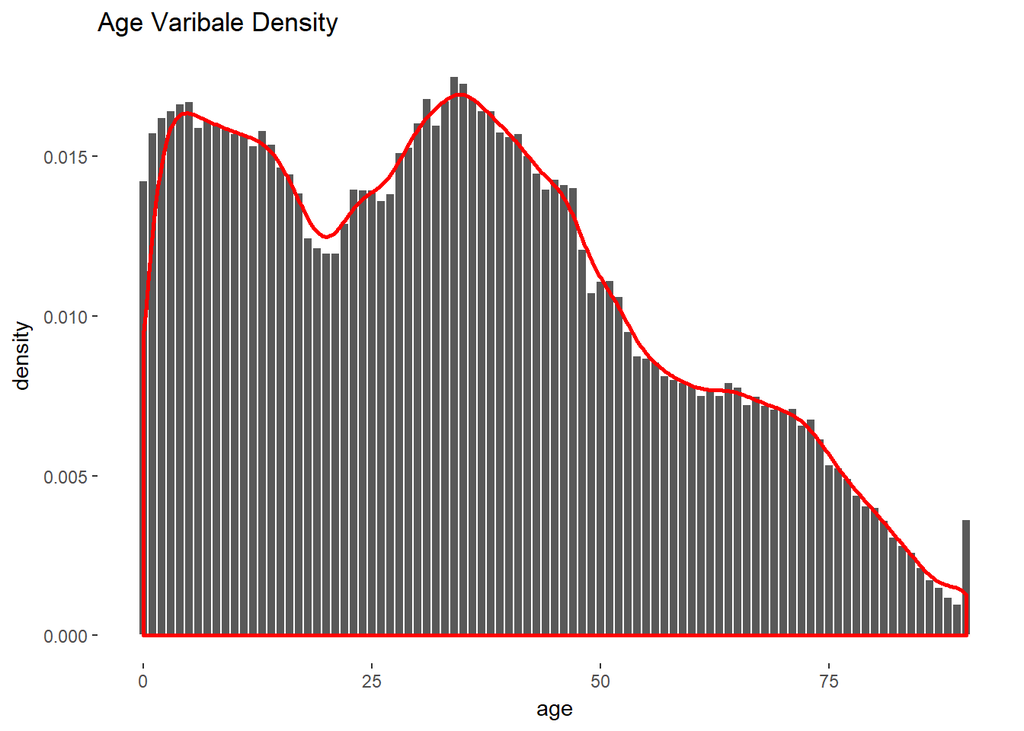

```r
ggplot(tr,aes(x=age,y=..density..)) +
  geom_histogram(color="white",binwidth = 1) + geom_density(col="red",size = 1)+
  theme(panel.background = element_blank()) + ggtitle("Age Varibale Density")
```

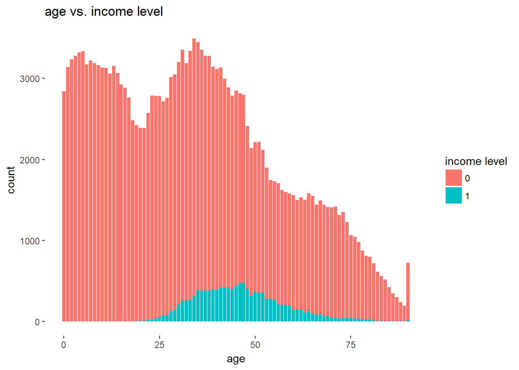

```r
ggplot(tr,aes(x=age,y=..count.., fill = as.factor(income_level))) +
  geom_bar() + theme(panel.background = element_blank()) + labs(fill = "income level")+
  ggtitle("age vs. income level")
```

#### 1.2 wage_per_hour

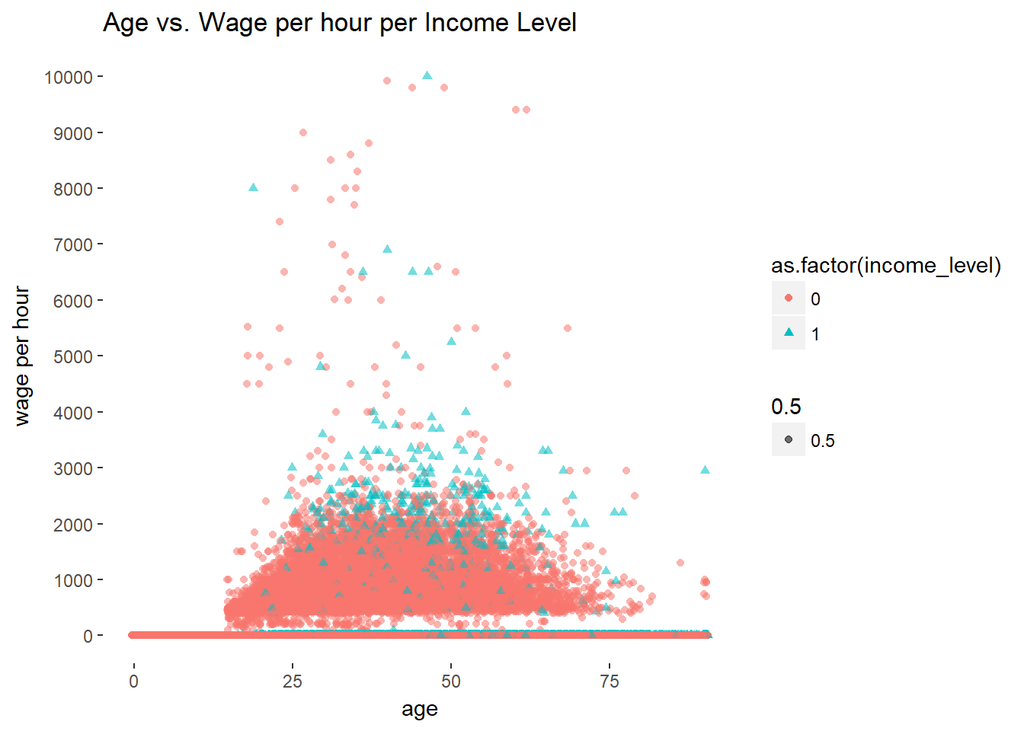

```r
ggplot(tr,aes(x=age,y= wage_per_hour)) +
  geom_jitter(aes(col=as.factor(income_level),alpha = 0.5, shape = as.factor(income_level))) + theme(panel.background = element_blank())+ labs(fill = "income level")+
  scale_y_continuous("wage per hour", breaks = seq(0,10000,1000)) +
  ggtitle("Age vs. Wage per hour per Income Level")
```

```r
Zero_value(tr$wage_per_hour)
```

```
   Zero_Per
1 0.9433449
```

#### 1.3 capital_gains

*96%* of the data in this variable has zero value  
The first plot shows the capital gain (I used Log2 for better visualization), Age, and Income_level distribution

```r
Zero_value(tr$capital_gains)
```

```
   Zero_Per
1 0.9630168
```

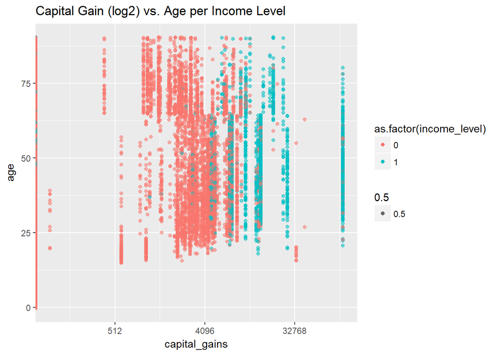

```r
ggplot(tr,aes(x=capital_gains,y=age,col=as.factor(income_level),alpha=0.5)) +
  geom_point(position="jitter")+scale_x_continuous(trans='log2') +labs(fill = "income level")+
  ggtitle("Capital Gain (log2) vs. Age per Income Level")
```

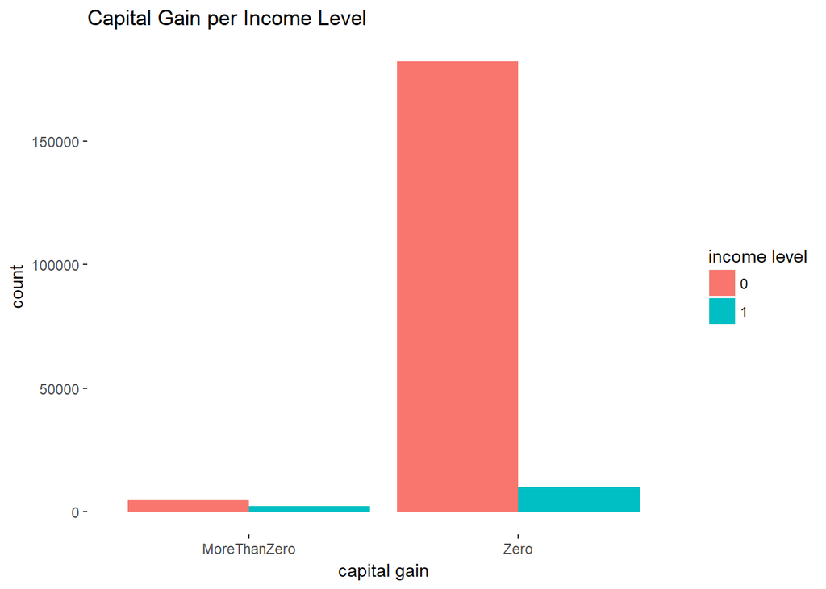

```r
ggplot(tr,aes(x=ifelse(capital_gains == 0,"Zero","MoreThanZero"),fill=as.factor(income_level))) + geom_bar(position="dodge")+ theme(panel.background = element_blank())+labs(fill = "income level")+
  labs(x="capital gain")+ggtitle("Capital Gain per Income Level")
```

#### 1.4 capital_losses

```r
Zero_value(tr$capital_losses)
```

```
   Zero_Per
1 0.9804233
```

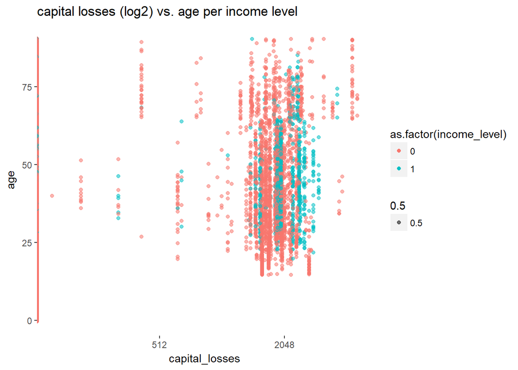

```r
ggplot(tr,aes(x=capital_losses,y=age,col=as.factor(income_level),alpha=0.5)) +
  geom_point(position="jitter")+scale_x_continuous(trans='log2') +
  theme(panel.background = element_blank())+labs(fill = "income level")+
  ggtitle("capital losses (log2) vs. age per income level")
```

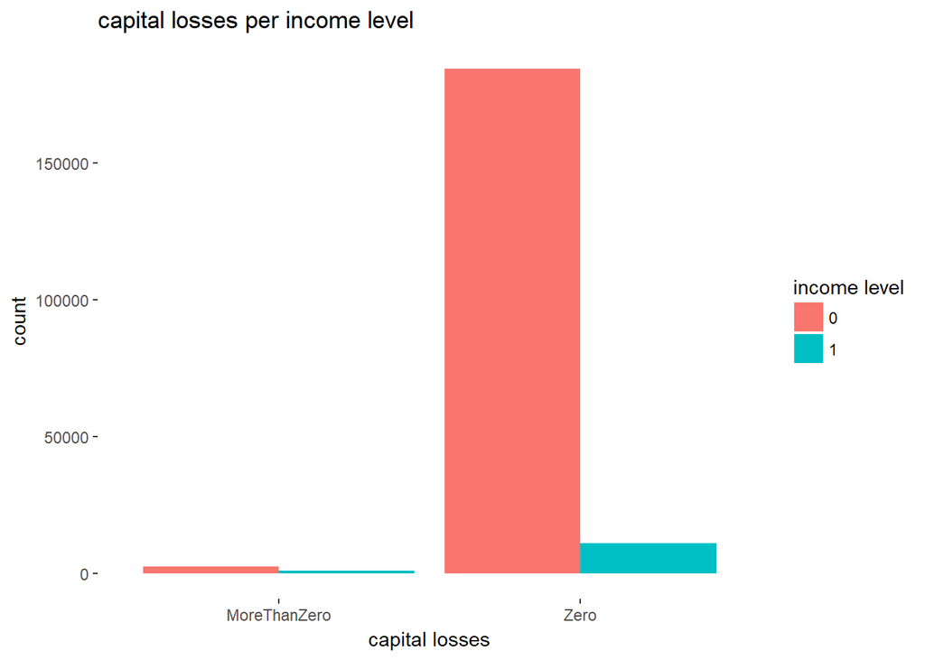

```r
ggplot(tr,aes(x=ifelse(capital_losses == 0,"Zero","MoreThanZero"),fill=as.factor(income_level))) +geom_bar(position="dodge")+
  theme(panel.background = element_blank())+labs(fill = "income level")+
  labs(x="capital losses")+ggtitle("capital losses per income level")
```

#### 1.5 dividend_from_Stocks

*89%* of the data has zero value Almost one-third of the people with dividend tend to get +50000, which is a high percentage comparing with the zero dividend category

```r
Zero_value(tr$dividend_from_Stocks)
```

```
   Zero_Per
1 0.8940423
```

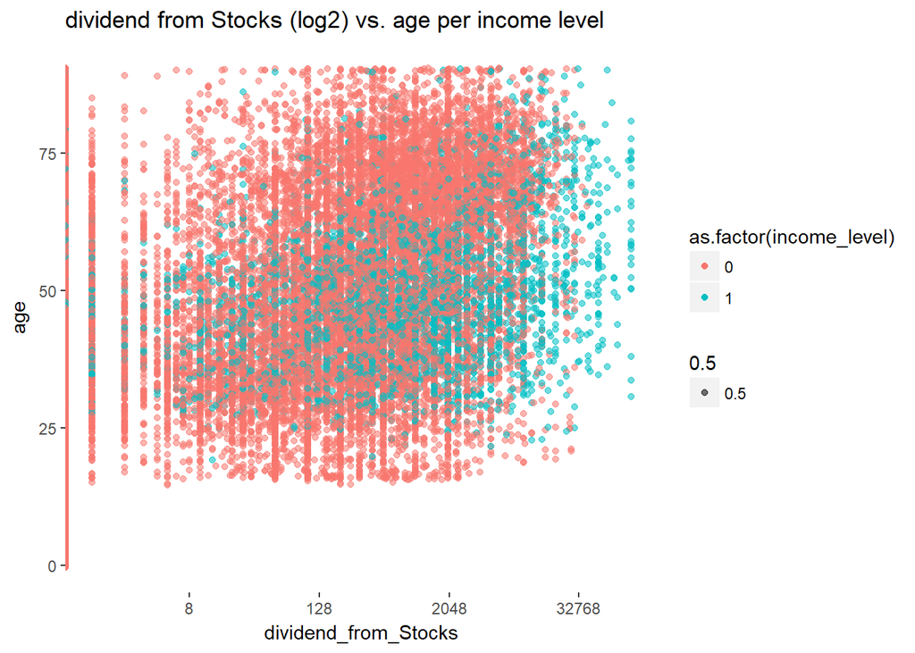

```r
ggplot(tr,aes(x=dividend_from_Stocks,y=age,col=as.factor(income_level),alpha=0.5)) +
  geom_point(position="jitter")+scale_x_continuous(trans='log2') +
  theme(panel.background = element_blank())+labs(fill = "income level")+
  ggtitle("dividend from Stocks (log2) vs. age per income level")
```

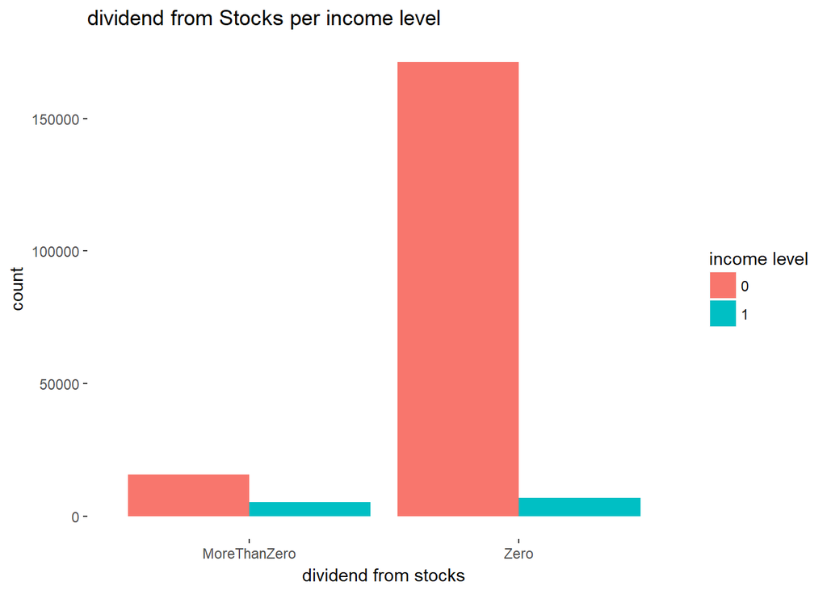

```r
ggplot(tr,aes(x=ifelse(dividend_from_Stocks == 0,"Zero","MoreThanZero"),fill=as.factor(income_level))) + geom_bar(position="dodge")+
  theme(panel.background = element_blank())+labs(fill = "income level")+
  labs(x="dividend from stocks")+ggtitle("dividend from Stocks per income level")
```

#### 1.6 num_person_Worked_employer

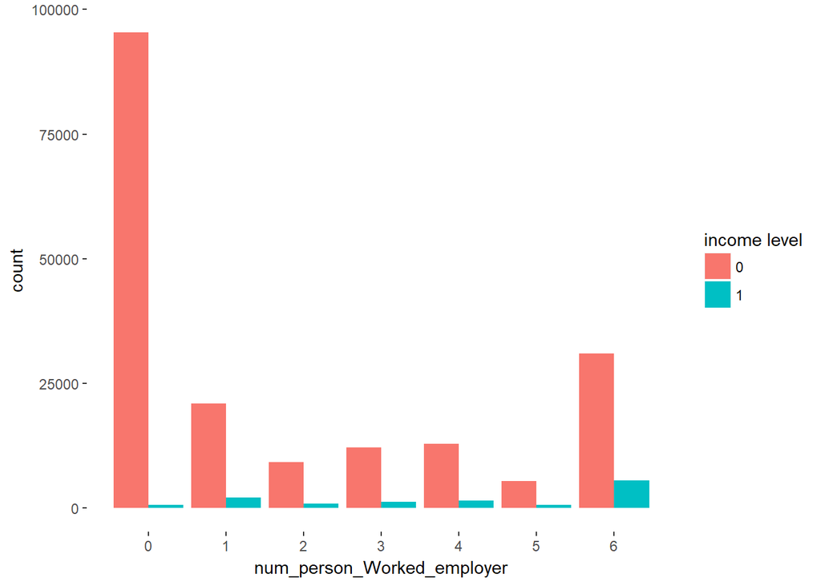

```r
ggplot(tr,aes(x=num_person_Worked_employer,y=..count.., fill = as.factor(income_level))) + geom_bar(position="dodge")+ scale_x_continuous("num_person_Worked_employer", breaks = seq(0,6,1)) + theme(panel.background = element_blank())+labs(fill = "income level")
```

```r
Zero_value(tr$num_person_Worked_employer) #48% zero values
```

```
   Zero_Per
1 0.4810623
```

#### 1.7 weeks_worked_in_year

For better visualization and because most of the values in this variable fall into 0 and 52, I grouped all the other values into one group (1 to 51 weeks) People who work 52 weeks have a higher probability of making +50000 income

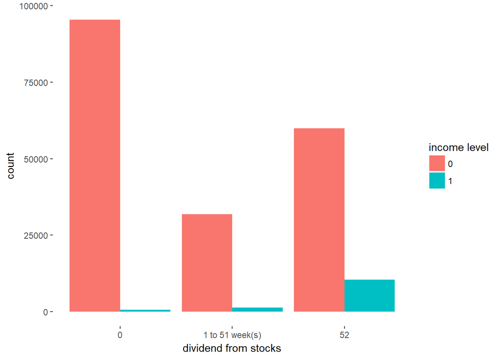

```r
ggplot(tr,aes(x=ifelse(weeks_worked_in_year == 0,"0",ifelse(weeks_worked_in_year==52,52,"1 to 51 week(s)")),y=..count.., fill = as.factor(income_level))) +
  geom_bar(position="dodge")+theme(panel.background = element_blank())+
  labs(fill = "income level")+labs(x="dividend from stocks")
```

#### 1.8 Correlation between numeric variables

Below we can see a visualization for the correlation matrix between the numeric variables.  
the target variable doesn’t have a good correlation with any numeric variables, the best correlation for the target variable is with weeks_worked_in_year and capital_gains (0.26 & 0.24 respectively)

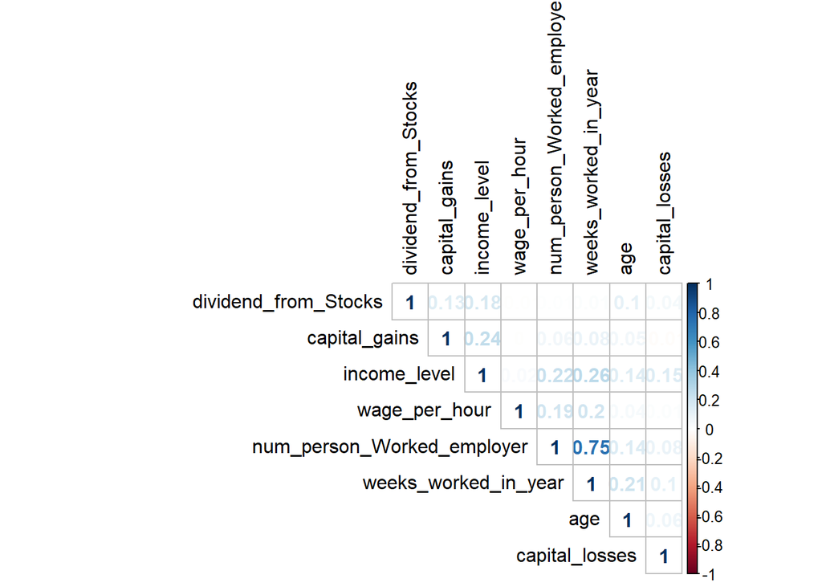

```r
numCor<-cor(tr[numcol])
corrplot(numCor, method = "number" , type = "upper", order = "hclust",
         tl.col = "black")
```

### 2. Categorical Variables

#### 2.1 class_of_worker

We can see that the majority of income level 1 fall into the private category  
The self-employed category has the highest percentage of people who has income level 1 (income level 1 / total people in the same category)

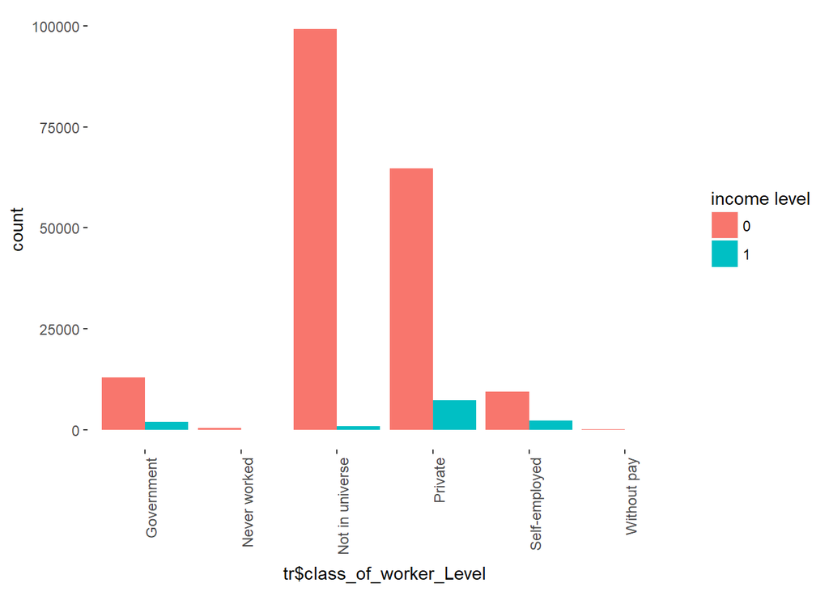

```r
ggplot(tr,aes(x = tr$class_of_worker_Level, fill = as.factor(income_level))) +
  geom_bar(position="dodge")+
  theme(panel.background = element_blank(),axis.text.x =element_text(angle  = 90,hjust = 1,size=9))+labs(fill = "income level")
```

#### 2.2 major_occupation_code & occupation_code

it’s clear that some occupations have a higher percentage of income level 1, especially: Executive admin and managerial, professional specialty and, sales  
We can dig deeper into each major occupation and its secondary occupation codes in the 2nd plot

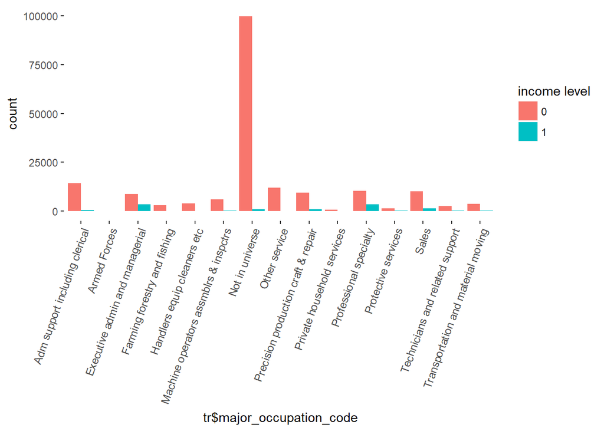

```r
ggplot(tr,aes(x = tr$major_occupation_code, fill = as.factor(income_level))) +
  geom_bar(position="dodge")+
  theme(panel.background = element_blank(),axis.text.x =element_text(angle  = 70,hjust = 1,size=9))+labs(fill = "income level")
```

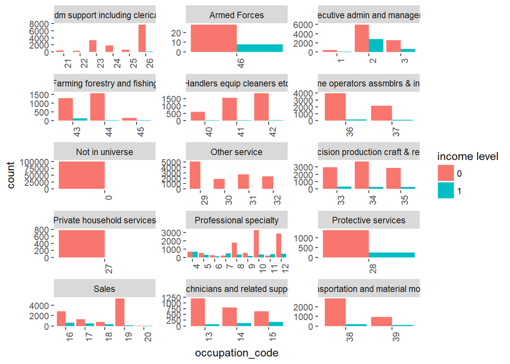

```r
ggplot(tr,aes(x = occupation_code, fill = as.factor(income_level))) + geom_bar(position="dodge")+
  theme(panel.background = element_blank(),axis.text.x =element_text(angle  = 90,hjust = 1,size=9))+
  facet_wrap(~major_occupation_code,scales = "free",ncol = 3)+labs(fill = "income level")
```

#### 2.3 education

More than 50% of the people who have Doctorate or prof school degrees have income level 1. also, we can say that master and Bachelors degrees have a high percentage of people with income level 1 comparing to rest of the degrees

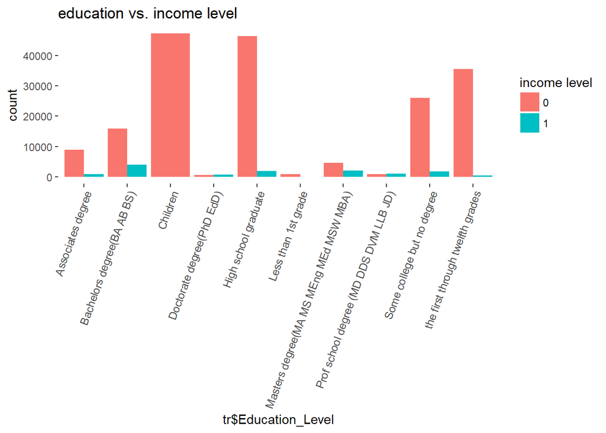

```r
ggplot(tr,aes(x =tr$Education_Level ,fill= as.factor(income_level))) + geom_bar(position="dodge")+
  theme(panel.background = element_blank(),axis.text.x =element_text(angle  = 70,hjust = 1,size=9)) + ggtitle("education vs. income level")+labs(fill = "income level")
```

#### 2.4 enrolled_in_edu_inst_lastwk

No obvious trend

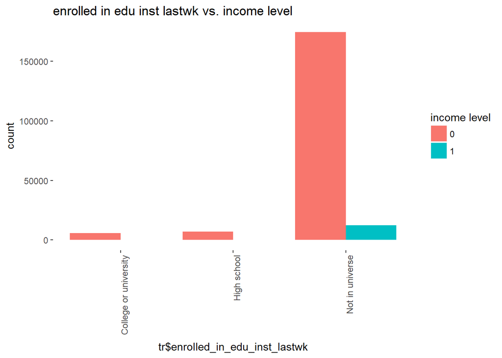

```r
ggplot(tr,aes(x = tr$enrolled_in_edu_inst_lastwk, fill = as.factor(income_level))) +
  geom_bar(position="dodge")+
  theme(panel.background = element_blank(),axis.text.x =element_text(angle  = 90,hjust = 1,size=9))+ggtitle("enrolled in edu inst lastwk vs. income level")+labs(fill = "income level")
```

#### 2.5 marital_status

The never-married category has a low percentage of the income level 1 which is understandable because the category contains people under 18, while married and divorced categories have a high percentage of income level 1

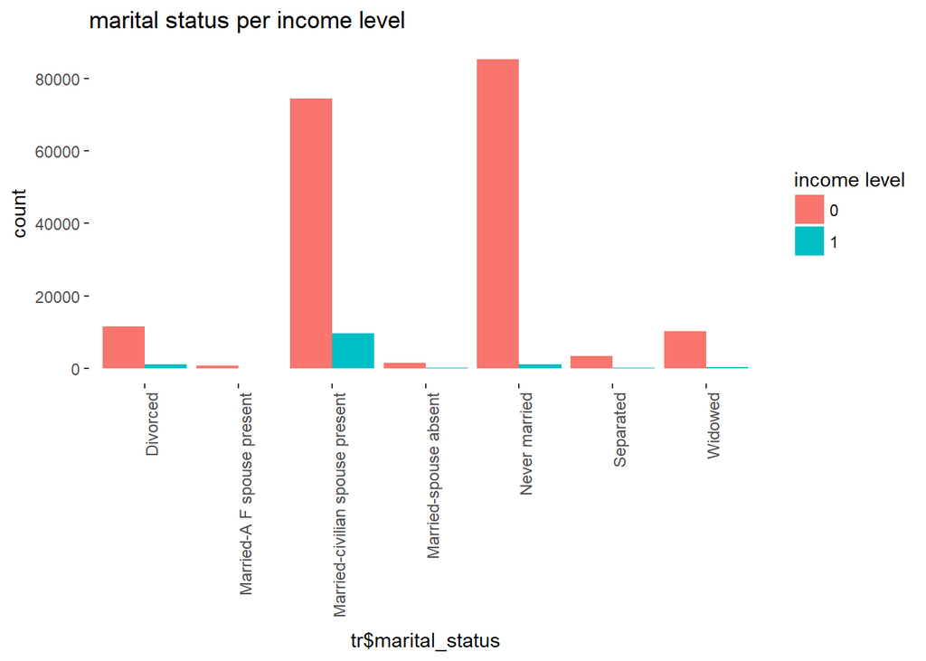

```r
ggplot(tr,aes(x = tr$marital_status, fill = as.factor(income_level))) +
  geom_bar(position="dodge")+
  theme(panel.background = element_blank(),axis.text.x =element_text(angle  = 90,hjust = 1,size=9))+  ggtitle("marital status per income level")+labs(fill = "income level")
```

#### 2.6 major_industry_code

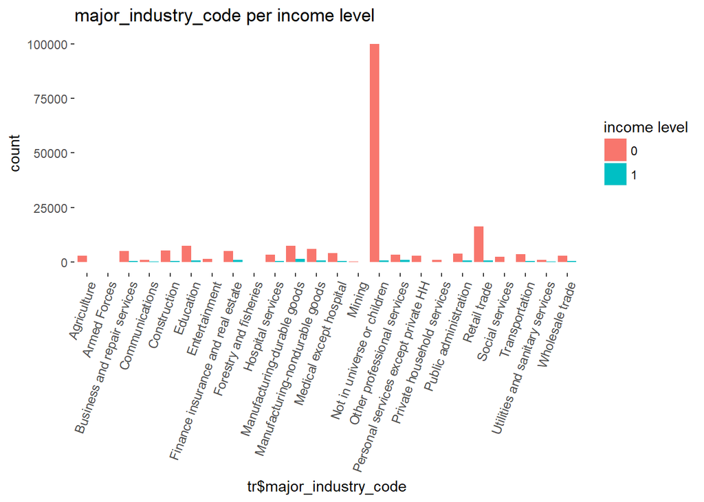

```r
ggplot(tr,aes(x = tr$major_industry_code, fill = as.factor(income_level))) +
  geom_bar(position="dodge")+theme(panel.background = element_blank(),axis.text.x =element_text(angle  = 70,hjust = 1,size=9))+
  ggtitle("major_industry_code per income level")+labs(fill = "income level")
```